# RepoSim

This requires the package be installed.

```r
knitr::opts_chunk$set(cache=TRUE)
#devtools::install_github("surbut/matrix_ash")
library("mash")
```

If you wanted to compute the denoised estimates using Extreme Deconvolution, you would need the Extreme Deconvolution package from Bovy et al as well, using the following package:

```r
library("ExtremeDeconvolution")
```

I simulated the data this way

```r
set.seed(123)
data=factor_sim_new(J = 20000)##simulate 20000 gene snp pairs with 400 true effects
saveRDS(data,"~/Dropbox/newsimdata.rds")
```

Here, I load my previously simulated data:

```r
data=readRDS("newsimdata.rds")
t=data$tstat;bhat=data$betahat;sebetahat=data$sebetahat;beta=data$beta;s.j=matrix(rep(1,ncol(t)*nrow(t)),ncol=ncol(t),nrow=nrow(t))
```

In this step, we run ash to choose the effects that satisfy a univariate ash lfsr threshold of 0.05 in at least one tissue. Again, you can choose to excecute this step yourself, but for your convenience, I’ve included these files in the directory.

```r
library('ashr')
t.fit=data$tstat
se.fit=data$sebetahat/data$sebetahat

univariate.ash.pm=matrix(nrow=nrow(t.fit),ncol=ncol(t.fit))
univariate.ash.lfsr=matrix(nrow=nrow(t.fit),ncol=ncol(t.fit))

for(x in 1:44){

b=ash(betahat=t.fit[,x],sebetahat=se.fit[,x],mixcompdist="normal")
univariate.ash.pm[,x]=b$PosteriorMean
univariate.ash.lfsr[,x]=b$lfsr
}

write.table(univariate.ash.lfsr,"~/Dropbox/univariate.ash.lfsrnewdata.txt")
write.table(univariate.ash.pm,"~/Dropbox/univariate.ash.pmnewdata.txt")
lfsr=read.table("univariate.ash.lfsrnewdata.txt")
index=which(rowSums(lfsr<0.05)>0)
write.table(t[index,],"maxtsim.txt",row.names = F,col.names = F)
```

Then we perform SFA on the maxes, however we choose to select them. I chose those which satisfied an LFSR threshold of 0.05 in at least one subgroup, and I saved the factors and loadings for your convenience in the directory as you can see. However, you can reperform yourslef with the SFA software installed.

```r
wc -l maxtsim.txt
##here there were 269 rows, so -g is 269
sfa -gen ./maxtsim.txt -g 269 -n 44 -o reproseed i -k 5
```

Then we load the loadings and factors and compute covariance matrices, train the model, and compute posteriors:

```r
factor.mat=as.matrix(read.table("reproseed_F.out"))
lambda.mat=as.matrix(read.table("reproseed_lambda.out"))
s.j=matrix(rep(1,ncol(t)*nrow(t)),ncol=ncol(t),nrow=nrow(t))

A="reproseedomega2"
cov=compute.covmat(b.gp.hat = t,sebetahat = s.j,Q =5, t.stat=t[index,],lambda.mat=lambda.mat,P=3,A=A, factor.mat = factor.mat,bma = TRUE,zero=TRUE,power = 2)$cov

compute.hm.train.log.lik.pen(train.b = t,se.train = s.j,covmat = cov,A=A,pen=1)


pis=readRDS(paste0("pis",A,".rds"))$pihat
b.test=t[1:20000,]
se.test=s.j[1:20000,]
weightedquants=lapply(seq(1:20000),function(j){total.quant.per.snp(j,cov,b.gp.hat=b.test,se.gp.hat = se.test,pis,A=A,checkpoint = FALSE)})
```

If we wanted to use the Extreme Deconvolution package, we could add an additional step. However, in this vignette we use the code above (without Extreme Deconvolution) to generate posteriors.

```r
library("ExtremeDeconvolution")
ms=deconvolution.em.with.bovy(t.stat=t[index,],factor.mat,s.j,lambda.mat,K=3,P=3)
saveRDS(ms,"mstruecovs.rds")
A="reproseedomegawithED"
coved=compute.hm.covmat.all.max.step(max.step = ms,b.gp.hat = t,sebetahat = s.j,Q =5, t.stat=t[index,],lambda.mat=lambda.mat,P=3,A=A, factor.mat = factor.mat,bma = TRUE,zero=TRUE,power = 2)$cov
```

You can look at the output of `ms$true.covs` to see how these estimates compare with the original covariance matrix, rank 5 SFA and rank 3 SVD decomposition respectively.

## Posteriors

After computing the posteriors, you should have files corresponding to the $\pi$ hierarchical weights and posterior quantities with the prefix you designated in A. I’ve included my computations in this directory using the prefix “reproseedomega2” for you to check your results.

Now let’s check the results:

```r
mash.means=read.table("reproseedomega2posterior.means.txt")[,-1]
univariate.ash.pm=read.table("univariateashpm.txt")
lfsr.mash=read.table("reproseedomega2lfsr.txt")[,-1]
lfsr.ash=read.table("univariate.ash.lfsrnewdata.txt")

sebetahat=data$sebetahat
sebetahat=sebetahat[1:20000,]
standard=sqrt(mean((beta[1:20000,]-bhat[1:20000,])^2))
sqrt(mean((beta[1:20000,]-mash.means[1:20000,]*sebetahat)^2))/standard
```

```
## [1] 0.06079755
```

```r
sqrt(mean((beta[1:20000,]-univariate.ash.pm[1:20000,]*sebetahat)^2))/standard
```

```
## [1] 0.2031151
```

Then, we can ask how many truly non-zero associations we capture at a given threshold.

```r
thresh=0.05


sum(sum(beta!=0&lfsr.mash<thresh))/sum(beta!=0)
```

```
## [1] 0.7428977
```

```r
sum(sum(beta!=0&lfsr.ash<thresh))/sum(beta!=0)
```

```
## [1] 0.1922727
```

Then, we compute the nominal lfsr (S) value, and we ask how many we correctly and incorrectly sign at a given threshold.

```r
sign.test.mash=beta*mash.means
sign.test.ash=beta*ash.means
###compute nominal lfsr threshold
mean(lfsr.mash[lfsr.mash<0.05])
```

```
## [1] 0.002034314
```

```r
mean(lfsr.ash[lfsr.ash<0.05])
```

```
## [1] 0.003686605
```

```r
##ask what proportion of associations do we correctly sign
sum(sign.test.mash>0&lfsr.mash<thresh)/sum(beta!=0)
```

```
## [1] 0.7397159
```

```r
sum(sign.test.ash>0&lfsr.ash<thresh)/sum(beta!=0)
```

```
## [1] 0.1922727
```

And here we plot a power comparison:

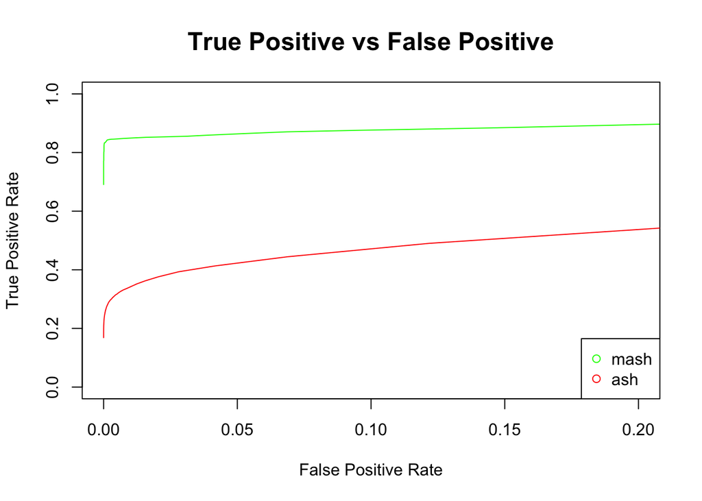

To show our calculations are correct, we show the calculation for a sample pair.

```r
j=sample.int(100,1)

A="reproseedomega2"

pis=readRDS(paste0("pis",A,".rds"))$pihat
b.test=t[1:20000,]
se.test=s.j[1:20000,]



covmat=readRDS(paste0("covmat",A,".rds"))
all.arrays=post.array.per.snp(j=j,covmat = covmat,b.gp.hat = t,se.gp.hat = s.j)

b.mle=as.vector(t(t[j,]))##turn i into a R x 1 vector
V.gp.hat=diag(s.j[j,])^2
V.gp.hat.inv <- solve(V.gp.hat)
k=3

U.gp1kl <- (post.b.gpkl.cov(V.gp.hat.inv, covmat[[k]]))
mu.gp1kl <- as.array(post.b.gpkl.mean(b.mle, V.gp.hat.inv, U.gp1kl))
#(all.arrays$post.means[k,])
all.equal(as.numeric(all.arrays$post.means[k,]),as.numeric(mu.gp1kl))
```

```
## [1] TRUE
```

Now, check to make sure weighting is correct

```r
post.means=as.matrix(read.table(paste0(A,"posterior.means.txt"))[,-1])
lik.snp=lik.func(b.mle,V.gp.hat,covmat)
post.weights=t(lik.snp*pis/sum(lik.snp*pis))

all.equal(as.numeric(post.means[j,]),as.numeric(post.weights%*%all.arrays$post.means))
```

```
## [1] TRUE
```

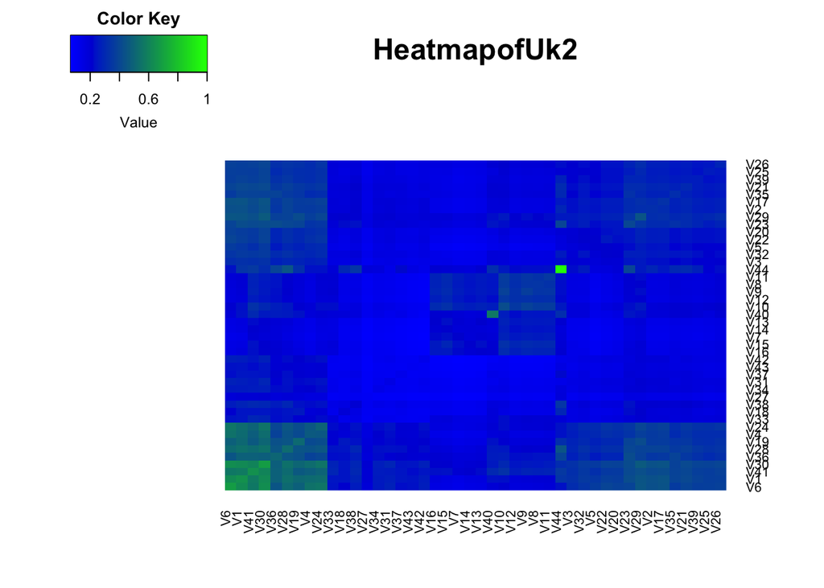

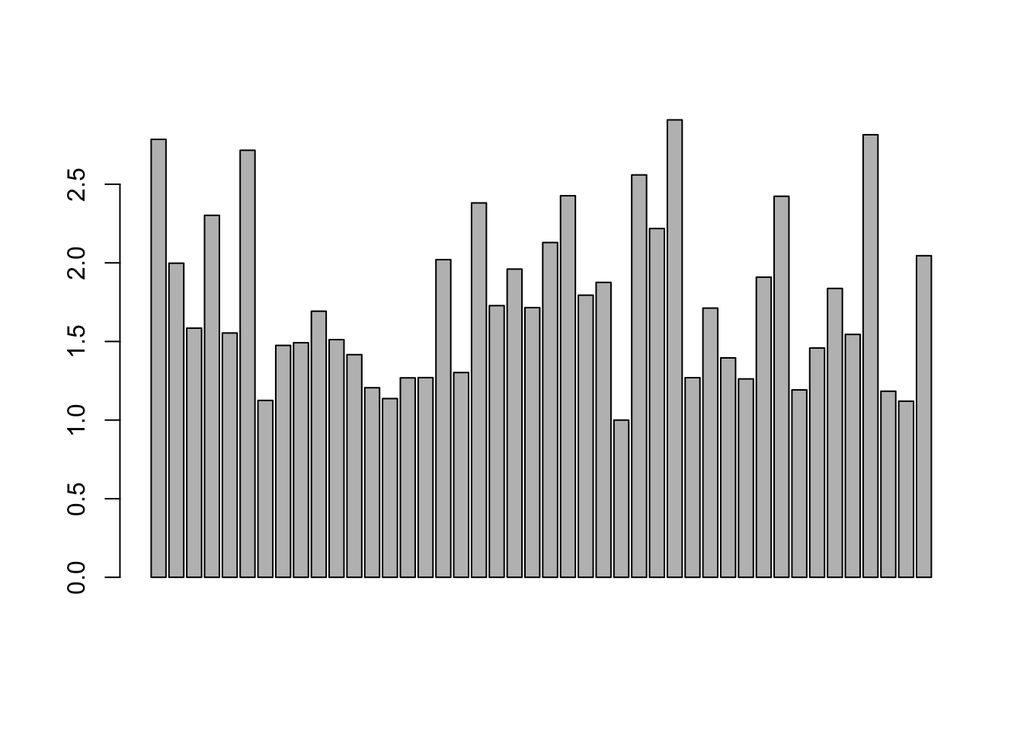

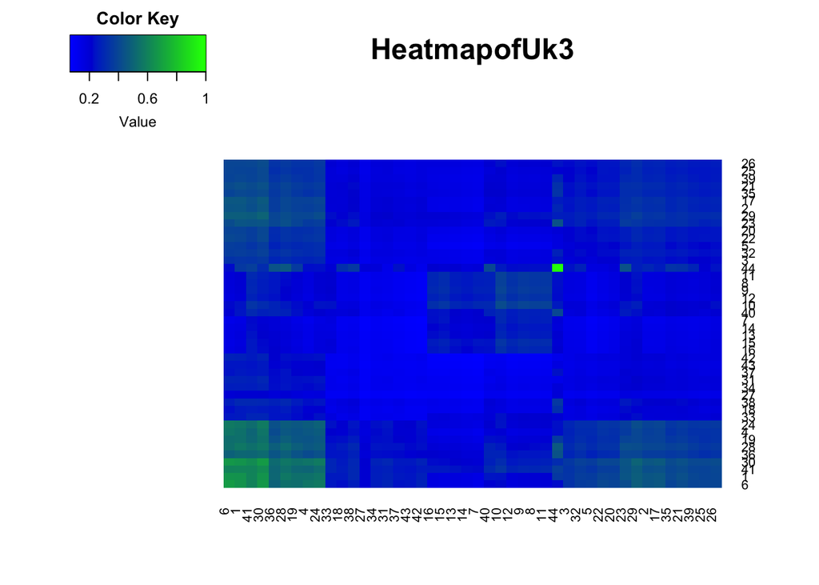

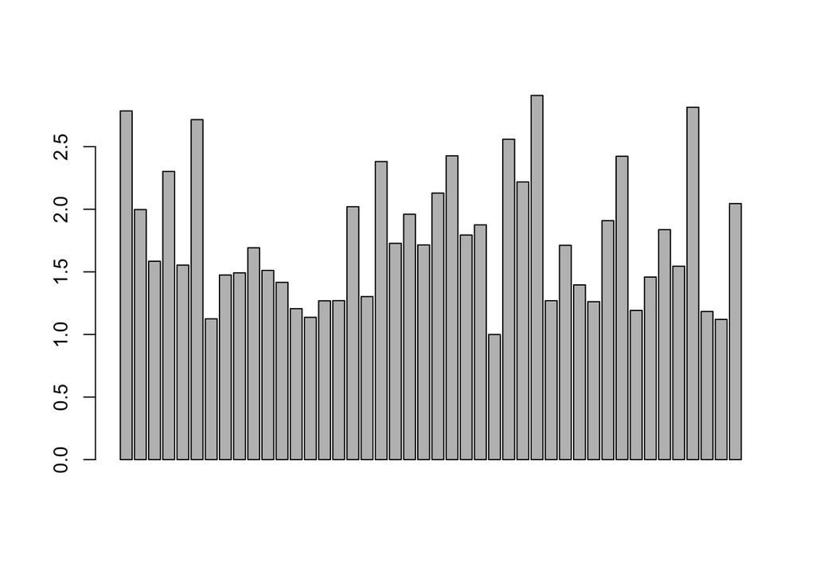

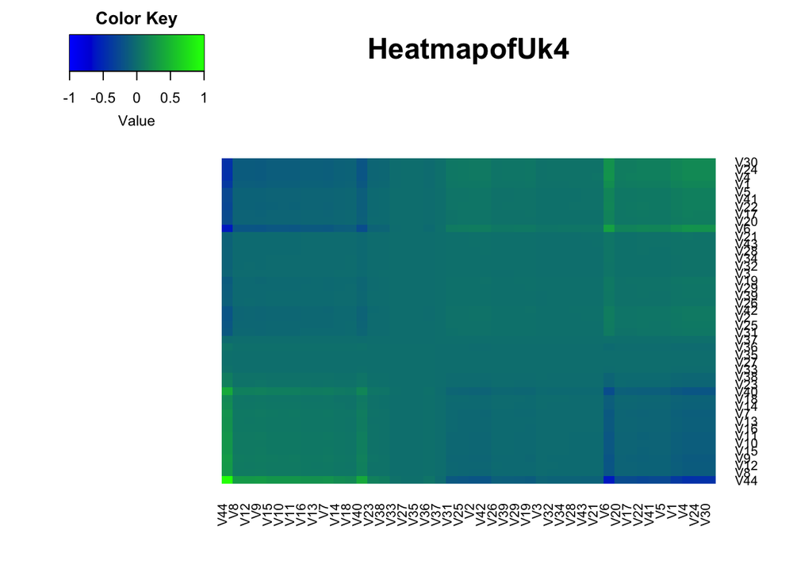

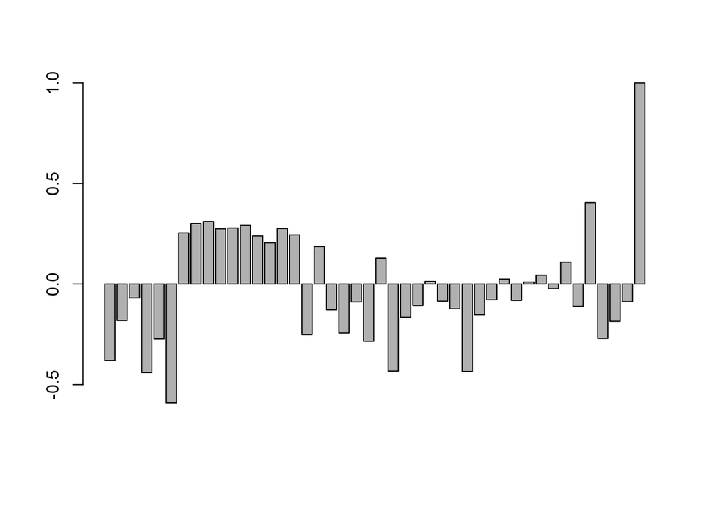

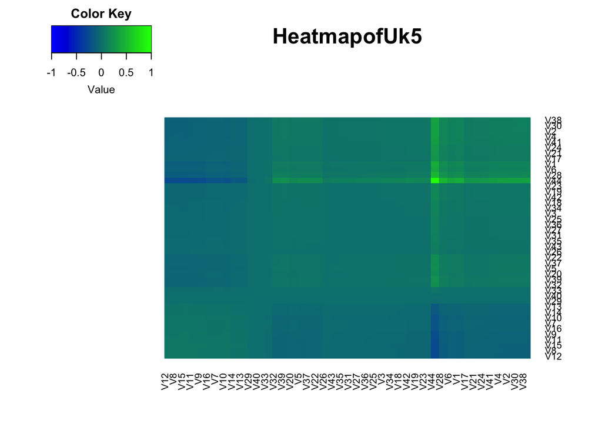

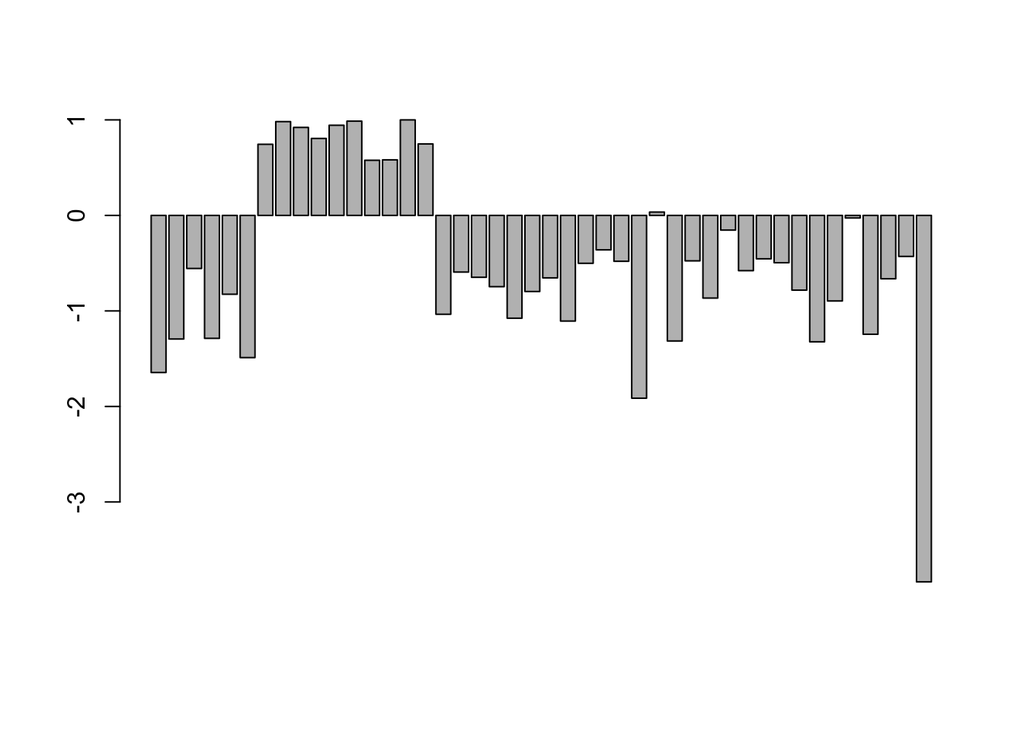

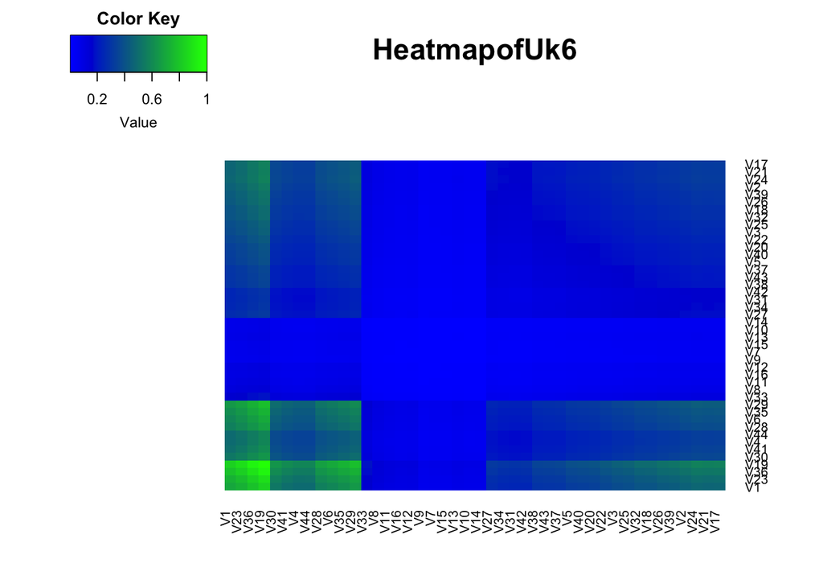

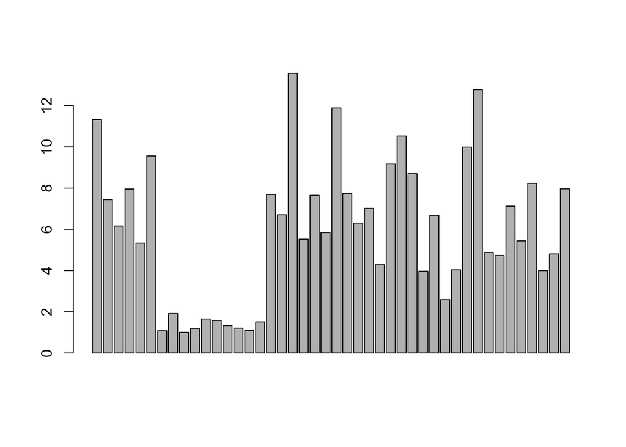

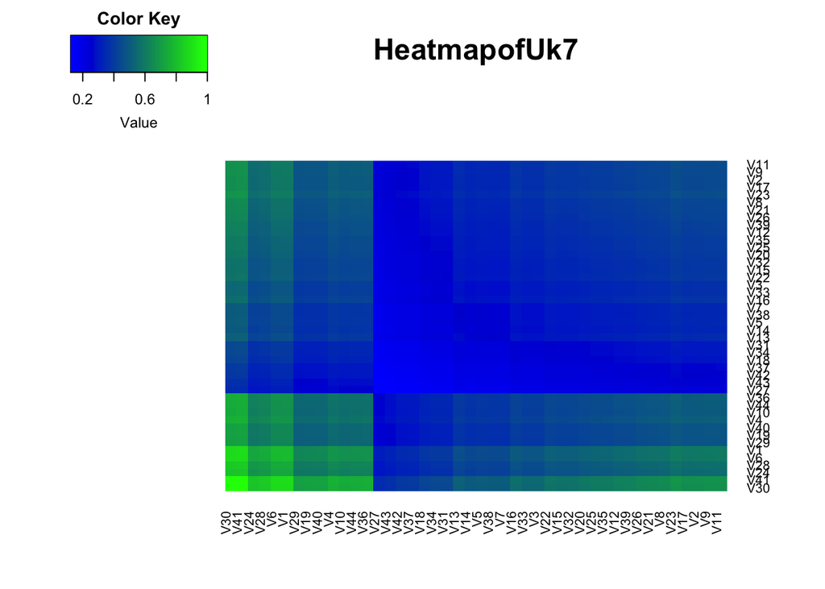

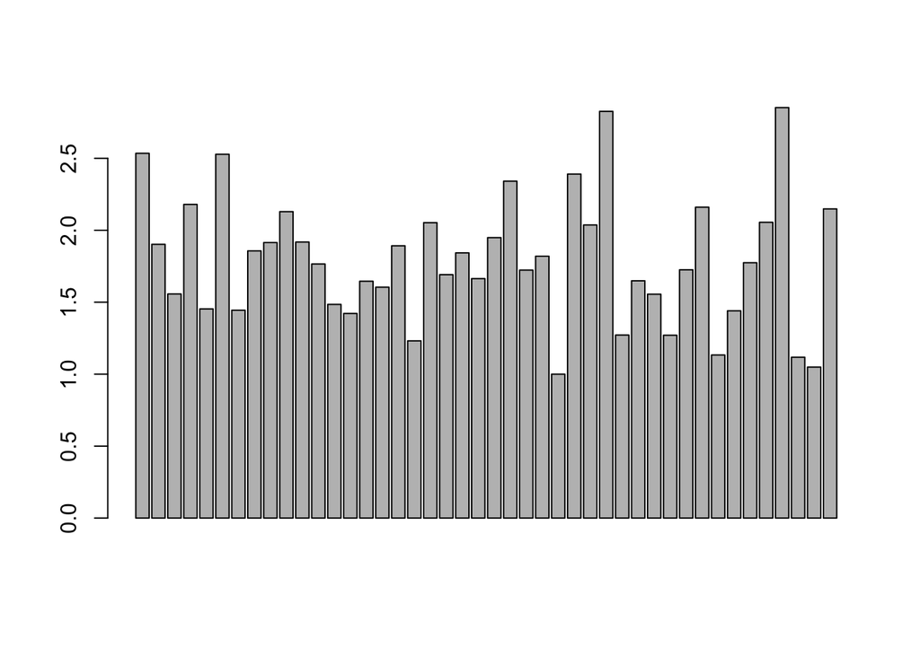

[4 more figures not shown]

```r
library('gplots')
library('colorRamps')
A="reproseedomega2"

pis=readRDS(paste0("pis",A,".rds"))$pihat

pi.mat=matrix(pis[-length(pis)],byrow = T,ncol=54)
cov=readRDS(paste0("covmat",A,".rds"))

mostimportant=c(2:9)
for(k in mostimportant){
  x=cov[[k]]/max(diag(cov[[k]]))

  heatmap.2(x,col = blue2green(256),dendrogram="none",density="none",trace="none",main=paste0("HeatmapofUk",k))
v=svd(cov[[k]])$v
barplot(v[,1]/max(v[,1]))
}
```